# Tourism_Impact_Analysis

Tourism Impact Analysis

**Authored by:** Taehwan Jung

**Duration:** 90 mins

**Level:** Intermediate

**Pre-requisite Skills:** Python, Haversine Distance, Folium Maps

**Scenario**

Understanding how tourists impact various regions of the city is important for enhancing tourism strategies and effectively addressing transportation and environmental challenges. The primary objective is to analyze pedestrian data to estimate the influence of tourists in different areas. By quantifying the impact of tourists on pedestrian activity, the city aims to make informed decisions that will improve urban planning, optimize resource allocation, and enhance the overall experience for both residents and visitors.

**User story**

As a city planner for Melbourne, I want to understand how tourists impact various regions of the city so that I can improve urban planning and optimize resource allocation needed for maintaining transportation and environmental sustainability.

What this use case will teach me is

At the end of this use case you will:

- learn how to load datasets using APIs
- learn how to create maps and visualize data
- learn how to analyze data relationship using correlation and regression analysis
- learn how to analyze data using Arima and clustering techniques

**Datasets**

**1. Pedestrian Counting per Hour:** Contains hourly data on the number of pedestrians counted at various sensor locations throughout Melbourne, including sensor IDs, timestamps, and location details.

**2. Bus Stops for Melbourne Visitor Shuttles:** Provides information on the locations of bus stops used by the Melbourne Visitor Shuttle service, including stop numbers, names, addresses, and coordinates.

**3. Public Artworks, Fountains, and Monuments:** Includes details about public artworks, fountains, and monuments across Melbourne, such as their names, asset types, artist information, and location coordinates.

**4. Domestic Visitor:** Contains data on domestic overnight visitors to Melbourne, including the number of visitors to Melbourne and regional Victoria, segmented by year and quarter.

## **Required modules**

```python
import requests
import pandas as pd
import numpy as np
from io import StringIO
import matplotlib.pyplot as plt
import seaborn as sns
import folium
import geopandas as gpd
from folium.plugins import MarkerCluster
from folium.plugins import feature_group_sub_group
from IPython.display import display
from sklearn.model_selection import train_test_split
from sklearn.linear_model import LinearRegression
from sklearn.metrics import mean_squared_error
from sklearn.metrics import mean_absolute_error
from statsmodels.tsa.arima.model import ARIMA
from statsmodels.tsa.statespace.sarimax import SARIMAX
from sklearn.cluster import KMeans
from matplotlib.cm import get_cmap
import matplotlib.colors as mcolors
from sklearn.preprocessing import MinMaxScaler
import warnings
warnings.filterwarnings('ignore')
```

## **Data loading**

```python
# Collect_data function
def collect_data(dataset_id):
    base_url = 'https://data.melbourne.vic.gov.au/api/explore/v2.1/catalog/datasets/'
    dataset_id = dataset_id
    format = 'csv'


    url = f'{base_url}{dataset_id}/exports/{format}'
    params = {
        'select': '*',
        'limit': -1,
        'lang': 'en',
        'timezone': 'UTC',
    }

    response = requests.get(url, params=params)


    if response.status_code == 200:
        url_content = response.content.decode('utf-8')
        dataset = pd.read_csv(StringIO(url_content), delimiter=';')
        return dataset
    else:
        print(f'Request failed with status code {response.status_code}')
```

Data1 (Pedestrian counting data) loading

```python
# Pedestrian counting data
dataset_id = 'pedestrian-counting-system-monthly-counts-per-hour'
data_1 = collect_data(dataset_id)
data_1.shape
```

```
(1850393, 9)
```

Data2 (Bus stops for Melbourne Visitor Shuttle) loading

```python
# Bus stop for Melbourne visitor shuttle data
dataset_id_2 = 'bus-stops-for-melbourne-visitor-shuttle'
data_2 = collect_data(dataset_id_2)
data_2.shape
```

```
(13, 4)
```

Data3 (Public artworks, fountains, and monuments) loading

```python
# Public artworks, fountains, and monuments data
dataset_id_3 = 'public-artworks-fountains-and-monuments'
data_3 = collect_data(dataset_id_3)
data_3.shape
```

```
(261, 14)
```

Data4 (Domestic visitors) loading

```python
# Domestic visitor data from visit victoria
#data_4 = pd.read_csv('/content/sample_data/Domestic overnight visitors.csv')
data_4 = pd.read_csv('https://raw.githubusercontent.com/Chameleon-company/MOP-Code/taehwan/datascience/usecases/DEPENDENCIES/Domestic_overnight_visitors.csv')
data_4.shape
```

```
(41, 3)
```

## **Data preprocessing**

```python
# Drop unnecessary features
data_3_cleaned = data_3.drop(columns=['easting', 'northing','xorg','xsource','artist','art_date','respective_author', 'structure', 'alternate_name'])
data_3_cleaned.head()
```

|  | asset_type | name | address_point | mel_way_ref | co_ordinates |
| --- | --- | --- | --- | --- | --- |
| 0 | Art | Blowhole | 13 Harbour Esplanade, DOCKLANDS | 2E_G8 | -37.8220182164578, 144.946871022845 |
| 1 | Art | Bandstand | 200 Little Collins Street, MELBOURNE | 2F_G3 | -37.8140548689972, 144.96733868317 |
| 2 | Art | Federation Bells | Birrarung Marr, MELBOURNE | 2F_ K6 | -37.8186738864394, 144.974167165492 |
| 3 | Art | Coat of Arms | 98 Swanston Street, MELBOURNE | 2F_F4 | -37.8151582937289, 144.966495940551 |
| 4 | Monument | Edmund Fitzgibbon Memorial | 208 St Kilda Road, SOUTHBANK | 2F_H9 | -37.8236122113264, 144.970418561306 |

Remove unnecessary columns from the tourist spots dataset

```python
# Na values check
data_1.isna().sum()
data_2.isna().sum()
data_3_cleaned.isna().sum()
data_4.isna().sum()
```

|  | 0 |
| --- | --- |
| DateTime | 0 |
| Melbourne | 0 |
| Regional VIC | 0 |

**dtype:** int64

Check if there are missing values in each dataset

```python
# To pandas datetime type
data_1_1 = data_1
data_1_1['sensing_date'] = pd.to_datetime(data_1['sensing_date'])
data_1_1['year_month'] = data_1_1['sensing_date'].dt.to_period('M').dt.end_time.dt.date
# Summing 'pedestriancount' by 'sensor_name', 'year_month', and 'location'
data_1_1 = data_1_1.groupby(['sensor_name', 'year_month', 'location']).agg({
    'pedestriancount': 'sum'
}).reset_index()
# Checking conversion
data_1_1.head()
```

|  | sensor_name | year_month | location | pedestriancount |
| --- | --- | --- | --- | --- |
| 0 | 261Will_T | 2022-11-30 | -37.81295822, 144.95678789 | 91518 |
| 1 | 261Will_T | 2022-12-31 | -37.81295822, 144.95678789 | 50214 |
| 2 | 261Will_T | 2023-01-31 | -37.81295822, 144.95678789 | 38818 |
| 3 | 261Will_T | 2023-05-31 | -37.81295822, 144.95678789 | 216910 |
| 4 | 261Will_T | 2023-06-30 | -37.81295822, 144.95678789 | 288651 |

Convert the date type to a pandas datetime format and aggregate the data on a monthly basis

```python
# Data_1 (pedestrian data) filtering for regression analysis
data_1_2 = data_1[data_1['sensing_date'].dt.year.isin([2021, 2022, 2023, 2024])]
data_1_2.head()
# 'sorting 'sensing_date' by quarter
data_1_2['year_quarter'] = data_1_2['sensing_date'].dt.to_period('Q')
# Summing 'pedestriancount' by 'year_quarter'
data_1_2 = data_1_2.groupby(['year_quarter']).agg({
    'pedestriancount': 'sum'
}).reset_index()
# Checking conversion
data_1_2.head()
```

|  | year_quarter | pedestriancount |
| --- | --- | --- |
| 0 | 2021Q3 | 19152943 |
| 1 | 2021Q4 | 33159337 |
| 2 | 2022Q1 | 37898480 |
| 3 | 2022Q2 | 46924338 |
| 4 | 2022Q3 | 48843359 |

Aggregate the pedestrian data quarterly. It will be used later in regression analysis

```python
# Data_1 filtering for Time series
data_1_3 = data_1
data_1_3['year_day'] = data_1_3['sensing_date'].dt.to_period('D').dt.end_time.dt.date
# Summing 'pedestriancount' by 'sensor_name', 'year_month', and 'location'
data_1_3 = data_1_3.groupby(['sensor_name', 'year_day', 'location']).agg({
    'pedestriancount': 'sum'
}).reset_index()
data_1_3.head()
```

|  | sensor_name | year_day | location | pedestriancount |
| --- | --- | --- | --- | --- |
| 0 | 261Will_T | 2022-11-17 | -37.81295822, 144.95678789 | 3993 |
| 1 | 261Will_T | 2022-11-18 | -37.81295822, 144.95678789 | 11594 |
| 2 | 261Will_T | 2022-11-19 | -37.81295822, 144.95678789 | 3200 |
| 3 | 261Will_T | 2022-11-20 | -37.81295822, 144.95678789 | 2855 |
| 4 | 261Will_T | 2022-11-21 | -37.81295822, 144.95678789 | 11506 |

Aggregate the pedestrian data daily. It will be used later in Time Series analysis

```python
# Convert datatype of 'data_4'(visitor_count data)
# To pandast datetime type
data_4['DateTime'] = pd.to_datetime(data_4['DateTime'])
# Data filtering
data_4_filtered = data_4[data_4['DateTime'].dt.year.isin([2021, 2022, 2023, 2024])]
data_4_filtered['DateTime'] = data_4_filtered['DateTime'].dt.to_period('Q')
data_4_filtered['year_quarter'] = data_4_filtered['DateTime']
# Dropping unecessary column
data_4_filtered = data_4_filtered.drop('DateTime',axis=1)
data_4_filtered = data_4_filtered.drop('Regional VIC',axis=1)
data_4_filtered = data_4_filtered.rename(columns={'Melbourne': 'visitor_count'})
# Checking result
data_4_filtered.head()
```

|  | visitor_count | year_quarter |
| --- | --- | --- |
| 28 | 2593347 | 2021Q1 |
| 29 | 3768841 | 2021Q2 |
| 30 | 4040786 | 2021Q3 |
| 31 | 4361704 | 2021Q4 |
| 32 | 4647179 | 2022Q1 |

Aggregate the tourist data quarterly. It will be used in regression analysis

```python
# Create columns of 'latitude'and 'longitude' for folium mapping
# data_1_1
data_1_1[['latitude', 'longitude']] = data_1_1['location'].str.split(',', expand=True)
data_1_1['latitude'] = pd.to_numeric(data_1_1['latitude'], errors='coerce')
data_1_1['longitude'] = pd.to_numeric(data_1_1['longitude'], errors='coerce')
# data_1_3
data_1_3[['latitude', 'longitude']] = data_1_3['location'].str.split(',', expand=True)
data_1_3['latitude'] = pd.to_numeric(data_1_3['latitude'], errors='coerce')
data_1_3['longitude'] = pd.to_numeric(data_1_3['longitude'], errors='coerce')
#data_2
data_2[['latitude', 'longitude']] = data_2['co_ordinates'].str.split(',', expand=True)
data_2['latitude'] = pd.to_numeric(data_2['latitude'], errors='coerce')
data_2['longitude'] = pd.to_numeric(data_2['longitude'], errors='coerce')
#data_3_cleaned
data_3_cleaned[['latitude', 'longitude']] = data_3_cleaned['co_ordinates'].str.split(',', expand=True)
data_3_cleaned['latitude'] = pd.to_numeric(data_3_cleaned['latitude'], errors='coerce')
data_3_cleaned['longitude'] = pd.to_numeric(data_3_cleaned['longitude'], errors='coerce')
data_3_cleaned['latitude'] = data_3_cleaned['latitude'].astype(float)
data_3_cleaned['longitude'] = data_3_cleaned['longitude'].astype(float)
#Checking results
print(data_1_3.head())
```

```
  sensor_name    year_day                    location  pedestriancount  \
0   261Will_T  2022-11-17  -37.81295822, 144.95678789             3993
1   261Will_T  2022-11-18  -37.81295822, 144.95678789            11594
2   261Will_T  2022-11-19  -37.81295822, 144.95678789             3200
3   261Will_T  2022-11-20  -37.81295822, 144.95678789             2855
4   261Will_T  2022-11-21  -37.81295822, 144.95678789            11506

    latitude   longitude
0 -37.812958  144.956788
1 -37.812958  144.956788
2 -37.812958  144.956788
3 -37.812958  144.956788
4 -37.812958  144.956788
```

Create latitude and longitude columns for each dataset

# Data visualization

```python
# Merge Pedestrian Data and Tourist Attraction Data on a Map
# Creating a map
map_melbourne = folium.Map(location=[-37.80841814,144.95906317], zoom_start=14, width=1000, height=600, control_scale=True)
# Pedestrian data
for index, row in data_1_1.iterrows():
    folium.CircleMarker(
        location=[row['latitude'], row['longitude']],
        radius=5,
        color='blue',
        fill=True,
        fill_color='blue',
        fill_opacity=0.6,
        popup=f"Location: {row['sensor_name']}<br>Count: {row['pedestriancount']}",
    ).add_to(map_melbourne)

# Tourist spots data
for index, row in data_3_cleaned.iterrows():
    folium.Marker(
        location=[row['latitude'], row['longitude']],
        popup=f"Name: {row['name']}<br>Type: {row['asset_type']}",
        icon=folium.Icon(color='green', icon='info-sign')
    ).add_to(map_melbourne)

# Adding a legend
legend_html = '''
<div style="position: fixed;
     top: 10px; left: 10px; width: 150px; height: 90px;
     border:2px solid grey; z-index:9999; font-size:14px;
     background-color: white; padding: 10px;">
     <b>Legend</b><br>
     <i style="color:blue;" class="fa fa-circle"></i> Pedestrian Count Sensor Locations<br>
     <i style="color:green;" class="fa fa-info-circle"></i> Tourist Spots</div>
'''
map_melbourne.get_root().html.add_child(folium.Element(legend_html))

# Map displaying
map_melbourne.save('melbourne_map.html')
display(map_melbourne)
```

Make this Notebook Trusted to load map: File -> Trust Notebook

[interactive chart not shown]

The map above visually represent the correlation between the pedestrian data and tourist spots data

```
   year_quarter  pedestriancount  visitor_count
0        2021Q3         19152943        4040786
1        2021Q4         33159337        4361704
2        2022Q1         37898480        4647179
3        2022Q2         46924338        5400025
4        2022Q3         48843359        7219067
5        2022Q4         54960213        8556485
6        2023Q1         57335887        9419538
7        2023Q2         58063867        9829835
8        2023Q3         63283379       10084297
9        2023Q4         70728077       10257111
10       2024Q1         69336334       10365636
```

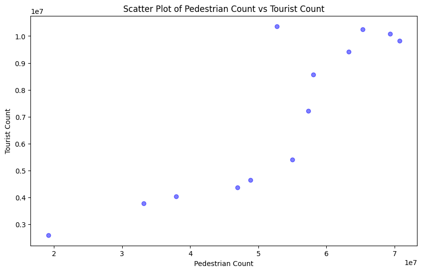

```python
# Dataset merge for scatter plot
merged_data_1 = pd.merge(data_1_2, data_4_filtered, on='year_quarter', how='inner')
# Merged_data checking
print(merged_data_1)

# Scatter plot
plt.figure(figsize=(10, 6))
plt.scatter(data_1_2['pedestriancount'], data_4_filtered['visitor_count'], color='blue', alpha=0.5)
plt.title('Scatter Plot of Pedestrian Count vs Tourist Count')
plt.xlabel('Pedestrian Count')
plt.ylabel('Tourist Count')
plt.show()
```

The scatter plot above shows the linear relationship between the pedestrian data and tourist data

# Data analysis

**Pearson Correalation Analysis**

```python
# Pearson Correlation Analysis(Pedestrian counting dataset and tourist dataset)
correlation = merged_data_1['pedestriancount'].corr(merged_data_1['visitor_count'])
print(f"Pearson Correlation Coefficient: {correlation}")
```

```
Pearson Correlation Coefficient: 0.9384815117290771
```

Conduct a Pearson correlation coefficient analysis on the total pedestrian data and tourist data for the same period. The result is very high, indicating a strong correlation.

**Regression Analysis**

```python
# Regression model
# 'fpedestriancount' is independent variable, 'visitor_count' is dependent variable
X = merged_data_1[['pedestriancount']]
y = merged_data_1['visitor_count']
# Dataset split
X_train, X_test, y_train, y_test = train_test_split(X, y, test_size=0.2, random_state=42)
# Regression model fit
model = LinearRegression()
model.fit(X_train, y_train)
# Regression model predict
y_pred = model.predict(X_test)
r_squared = model.score(X, y)
mae = mean_absolute_error(y_test, y_pred)
mse = mean_squared_error(y_test, y_pred)
# Regression model results
print(merged_data_1)
print(f"Regression Coefficient: {model.coef_}")
print(f"R-squared: {r_squared}")
print(f"Mean Absolute Error: {mae}")
print(f"Mean Squared Error (MSE): {mse}")
```

```
   year_quarter  pedestriancount  visitor_count
0        2021Q3         19152943        4040786
1        2021Q4         33159337        4361704
2        2022Q1         37898480        4647179
3        2022Q2         46924338        5400025
4        2022Q3         48843359        7219067
5        2022Q4         54960213        8556485
6        2023Q1         57335887        9419538
7        2023Q2         58063867        9829835
8        2023Q3         63283379       10084297
9        2023Q4         70728077       10257111
10       2024Q1         69336334       10365636
Regression Coefficient: [0.19797284]
R-squared: 0.8006500040727327
Mean Absolute Error: 1423366.9560733212
Mean Squared Error (MSE): 3168240628361.365
```

Base on the Pearson correlation coefficient result indicating a strong correlation, conduct a regression analysis of the two datasets. Examine the regression coefficient to determine the relationship between the pedestrian data and tourist data, and review the MAE, MSE, and R-squared results to verify the accuracy of the analysis.

**Estimation of Regional Tourist Numbers Using the Regression Coefficient**

```python
# Regression_coefficient
regression_coefficient = 0.198
# Estimation regional tourists numbers
data_1_1_estimation = data_1_1.copy()
data_1_1_estimation['estimated_tourist_count'] = data_1_1['pedestriancount'] * regression_coefficient
print(data_1_1_estimation.head(10))
print(data_1_1_estimation.shape)
```

```
  sensor_name  year_month                    location  pedestriancount  \
0   261Will_T  2022-11-30  -37.81295822, 144.95678789            91518
1   261Will_T  2022-12-31  -37.81295822, 144.95678789            50214
2   261Will_T  2023-01-31  -37.81295822, 144.95678789            38818
3   261Will_T  2023-05-31  -37.81295822, 144.95678789           216910
4   261Will_T  2023-06-30  -37.81295822, 144.95678789           288651
5   261Will_T  2023-07-31  -37.81295822, 144.95678789           314142
6   261Will_T  2023-08-31  -37.81295822, 144.95678789           343645
7   261Will_T  2023-09-30  -37.81295822, 144.95678789           303683
8   261Will_T  2023-10-31  -37.81295822, 144.95678789           328492
9   261Will_T  2023-11-30  -37.81295822, 144.95678789           316824

    latitude   longitude  estimated_tourist_count
0 -37.812958  144.956788                18120.564
1 -37.812958  144.956788                 9942.372
2 -37.812958  144.956788                 7685.964
3 -37.812958  144.956788                42948.180
4 -37.812958  144.956788                57152.898
5 -37.812958  144.956788                62200.116
6 -37.812958  144.956788                68041.710
7 -37.812958  144.956788                60129.234
8 -37.812958  144.956788                65041.416
9 -37.812958  144.956788                62731.152
(2847, 7)
```

Use the regression coefficient to extract the proportion of tourists for each sensor from the pedestrian data.

**Matching the closest pedestrian counting sensor to a tourist spot**

```python
# Calculating the distance between the sensor location and tourist spots location using Haversine
def haversine(lat1, lon1, lat2, lon2):
    R = 6371.0
    phi1 = np.radians(lat1)
    phi2 = np.radians(lat2)
    delta_phi = np.radians(lat2 - lat1)
    delta_lambda = np.radians(lon2 - lon1)

    a = np.sin(delta_phi / 2.0) ** 2 + np.cos(phi1) * np.cos(phi2) * np.sin(delta_lambda / 2.0) ** 2
    c = 2 * np.arctan2(np.sqrt(a), np.sqrt(1 - a))

    return R * c
# Matching tourist spots and the neartest sensor location
def match_closest_pedestrian_data(tourist_data, pedestrian_data):
    matches = []

    for _, tour_row in tourist_data.iterrows():
        min_distance = float('inf')
        closest_pedestrian = None

        for _, ped_row in pedestrian_data.iterrows():
            distance = haversine(tour_row['latitude'], tour_row['longitude'], ped_row['latitude'], ped_row['longitude'])
            if distance < min_distance:
                min_distance = distance
                closest_pedestrian = ped_row
        estimated_tourist_count = closest_pedestrian['pedestriancount'] * regression_coefficient

        matches.append({
            'tourist_location': tour_row['name'],
            'pedestrian_sensor': closest_pedestrian['sensor_name'],
            'pedestrian_count': closest_pedestrian['pedestriancount'],
            'distance_km': min_distance,
            'tour_latitude' : tour_row['latitude'],
            'tour_longitude' : tour_row['longitude'],
            'estimated_tourist_count' : estimated_tourist_count,
            })

    return pd.DataFrame(matches)
# Matching results
matched_data = match_closest_pedestrian_data(data_3_cleaned, data_1_1_estimation)
print(matched_data)
```

```
                tourist_location pedestrian_sensor  pedestrian_count  \
0                       Blowhole           WebBN_T             80218
1                      Bandstand          Bou231_T            178078
2               Federation Bells      BirFed1120_T             88316
3                   Coat of Arms          Swa123_T            257070
4     Edmund Fitzgibbon Memorial             VAC_T            378528
..                           ...               ...               ...
256       Dinny O'Hearn Fountain          Lyg309_T            110294
257  Westgarth Drinking Fountain          Spr201_T             68561
258     Pioneer Women's Memorial             VAC_T            378528
259                Painted Poles           SwaCs_T            152538
260                        Angel      BirFed1120_T             88316

     distance_km  tour_latitude  tour_longitude  estimated_tourist_count
0       0.105429     -37.822018      144.946871                15883.164
1       0.095419     -37.814055      144.967339                35259.444
2       0.059180     -37.818674      144.974167                17486.568
3       0.047369     -37.815158      144.966496                50899.860
4       0.294161     -37.823612      144.970419                74948.544
..           ...            ...             ...                      ...
256     0.054349     -37.797599      144.967306                21838.212
257     0.554235     -37.805091      144.973417                13575.078
258     0.767606     -37.825115      144.976076                74948.544
259     0.005837     -37.815741      144.966836                30202.524
260     0.081072     -37.818954      144.972959                17486.568

[261 rows x 7 columns]
```

Match each tourist spot with the nearest pedestrian sensor to estimate the number of tourists.

**Time series prediction**

```python
# Preprocessing for time series prediction
data_1_3_estimation = data_1_3.copy()
data_1_3_estimation['year_day'] = pd.to_datetime(data_1_3_estimation['year_day'])
data_1_3_estimation['estimated_tourist_count'] = data_1_3['pedestriancount'] * regression_coefficient
# Drop duplicate sensor 'BirBridge_T'
data_1_3_estimation = data_1_3_estimation[data_1_3_estimation['sensor_name'] != 'BirBridge_T']
```

```
Processing sensor: 261Will_T
AIC for sensor 261Will_T: 7026.453289049711
BIC for sensor 261Will_T: 7055.310738716312
RMSE for sensor 261Will_T: 1511.1323198827379
Forecast for sensor 261Will_T:
2024-02-29    2958.128539
2024-03-01    2277.846615
2024-03-02    1354.034462
2024-03-03    1870.068571
2024-03-04    2368.833645
                 ...
2024-09-13    3029.898960
2024-09-14    2942.825294
2024-09-15    3001.606386
2024-09-16    2982.194376
2024-09-17    3058.640963
Freq: D, Name: predicted_mean, Length: 202, dtype: float64

Forecast Increase for sensor 261Will_T: 100.51242434579945
```

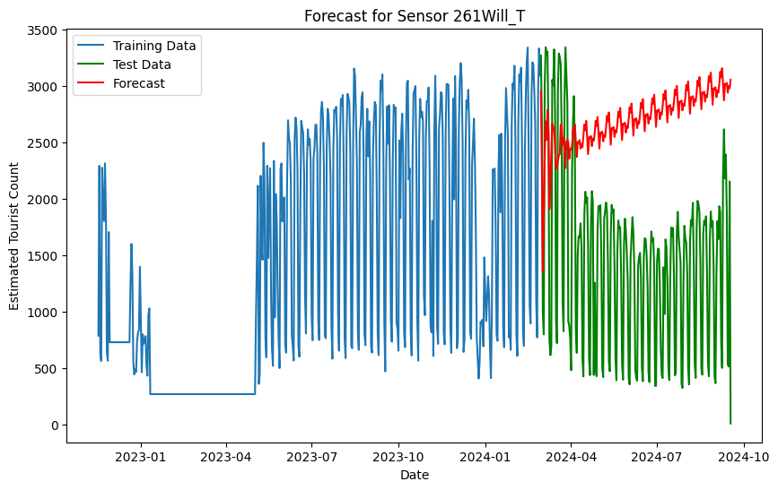

```
Processing sensor: 280Will_T
AIC for sensor 280Will_T: 5890.875478785476
BIC for sensor 280Will_T: 5919.7329284520765
RMSE for sensor 280Will_T: 698.5605263485924
Forecast for sensor 280Will_T:
2024-02-29    234.624443
2024-03-01    204.916833
2024-03-02    159.874823
2024-03-03    196.698236
2024-03-04    165.566074
                 ...
2024-09-13   -254.323835
2024-09-14   -257.643967
2024-09-15   -255.914096
2024-09-16   -252.780675
2024-09-17   -251.120044
Freq: D, Name: predicted_mean, Length: 202, dtype: float64

Forecast Increase for sensor 280Will_T: -485.7444864546457
```

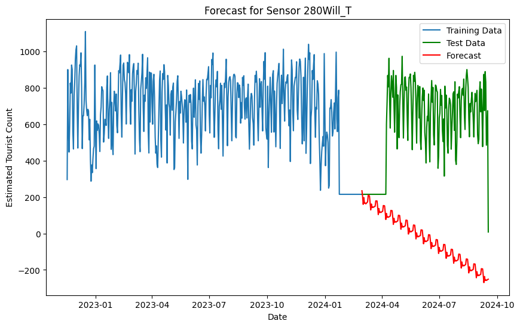

```
Processing sensor: 474Fl_T
AIC for sensor 474Fl_T: 2697.335205115518
BIC for sensor 474Fl_T: 2720.630338297045
RMSE for sensor 474Fl_T: 166.60536942428251
Forecast for sensor 474Fl_T:
2024-06-16    829.618628
2024-06-17    814.165051
2024-06-18    754.447565
2024-06-19    729.296073
2024-06-20    716.673764
                 ...
2024-09-13    811.476785
2024-09-14    768.027626
2024-09-15    746.754279
2024-09-16    780.489191
2024-09-17    795.153863
Freq: D, Name: predicted_mean, Length: 94, dtype: float64

Forecast Increase for sensor 474Fl_T: -34.46476454352353
```

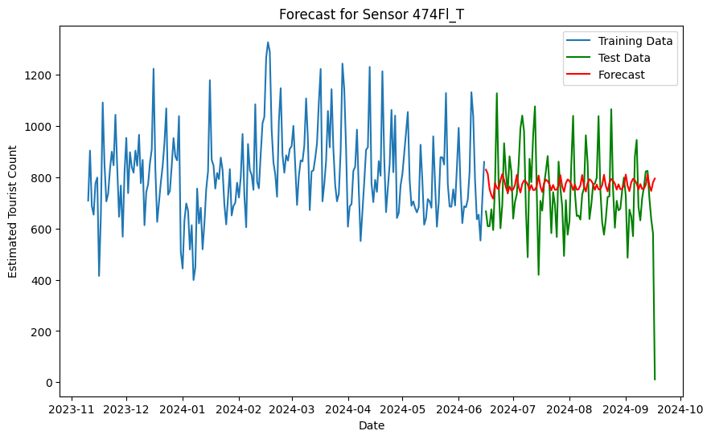

```
Processing sensor: 488Mac_T
AIC for sensor 488Mac_T: 7546.798768227697
BIC for sensor 488Mac_T: 7578.53529009323
RMSE for sensor 488Mac_T: 111.58130698598029
Forecast for sensor 488Mac_T:
2023-11-22    421.290905
2023-11-23    426.814054
2023-11-24    445.853751
2023-11-25    431.060836
2023-11-26    440.632084
                 ...
2024-09-13    482.019643
2024-09-14    491.343104
2024-09-15    486.866084
2024-09-16    482.180536
2024-09-17    479.362252
Freq: D, Name: predicted_mean, Length: 301, dtype: float64

Forecast Increase for sensor 488Mac_T: 58.07134636677921
```

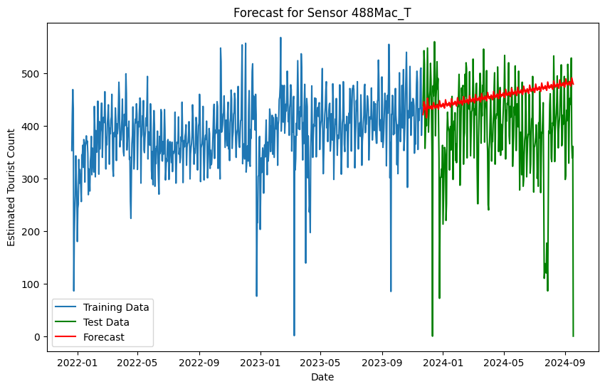

```
Processing sensor: 574Qub_T
AIC for sensor 574Qub_T: 7342.032735903962
BIC for sensor 574Qub_T: 7373.769257769495
RMSE for sensor 574Qub_T: 73.01348328077825
Forecast for sensor 574Qub_T:
2023-11-22    234.745747
2023-11-23    245.834492
2023-11-24    245.608910
2023-11-25    254.030389
2023-11-26    254.698691
                 ...
2024-09-13    236.256066
2024-09-14    236.352963
2024-09-15    238.587049
2024-09-16    236.454078
2024-09-17    224.248055
Freq: D, Name: predicted_mean, Length: 301, dtype: float64

Forecast Increase for sensor 574Qub_T: -10.497692136336497
```

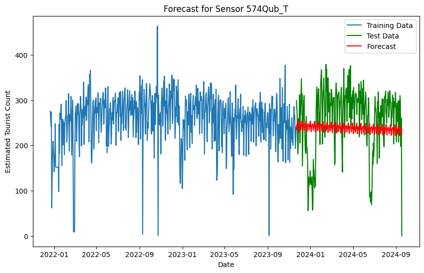

```
Processing sensor: ACMI_T
AIC for sensor ACMI_T: 12480.645958904983
BIC for sensor ACMI_T: 12513.516551324392
RMSE for sensor ACMI_T: 942.2366616533537
Forecast for sensor ACMI_T:
2023-10-01    2211.387470
2023-10-02    2037.754378
2023-10-03    2141.445812
2023-10-04    2191.600717
2023-10-05    2409.819648
                 ...
2024-09-13    2689.532577
2024-09-14    2755.782696
2024-09-15    2909.438537
2024-09-16    2861.295840
2024-09-17    2788.074379
Freq: D, Name: predicted_mean, Length: 353, dtype: float64

Forecast Increase for sensor ACMI_T: 576.6869092576485
```

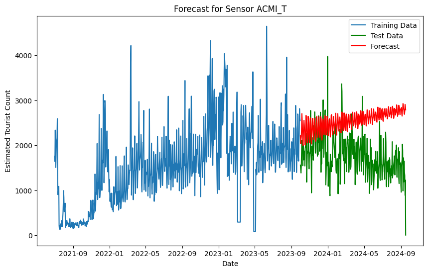

```
Processing sensor: AG_T
AIC for sensor AG_T: 13667.671057793334
BIC for sensor AG_T: 13700.541650212743
RMSE for sensor AG_T: 1094.128882335138
Forecast for sensor AG_T:
2023-10-01    2213.938201
2023-10-02    2032.961600
2023-10-03    1968.677605
2023-10-04    1587.478091
2023-10-05    1568.913740
                 ...
2024-09-13    2193.194025
2024-09-14    2141.516575
2024-09-15    2166.164648
2024-09-16    1841.209335
2024-09-17    1859.441922
Freq: D, Name: predicted_mean, Length: 353, dtype: float64

Forecast Increase for sensor AG_T: -354.4962792515116
```

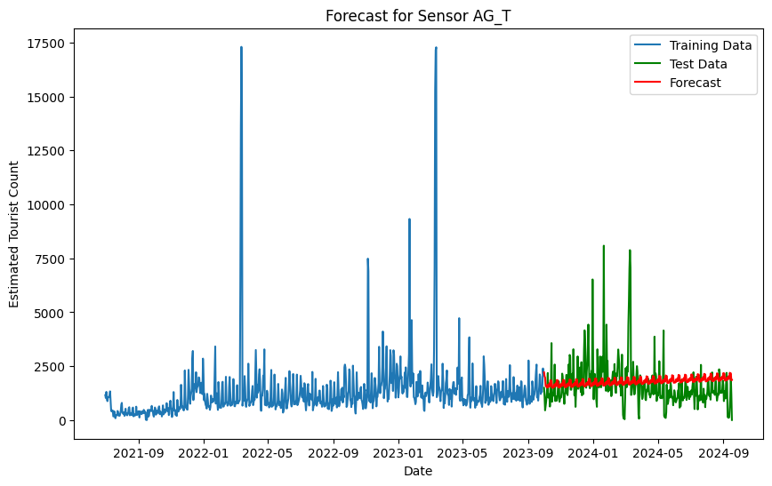

```
Processing sensor: AlfPl_T
AIC for sensor AlfPl_T: 10085.103814417285
BIC for sensor AlfPl_T: 10117.974406836694
RMSE for sensor AlfPl_T: 232.75648051999664
Forecast for sensor AlfPl_T:
2023-10-01    436.940971
2023-10-02    553.159855
2023-10-03    596.241807
2023-10-04    592.038288
2023-10-05    530.731526
                 ...
2024-09-13    606.809043
2024-09-14    611.669968
2024-09-15    598.281874
2024-09-16    615.985656
2024-09-17    594.782422
Freq: D, Name: predicted_mean, Length: 353, dtype: float64

Forecast Increase for sensor AlfPl_T: 157.8414509927755
```

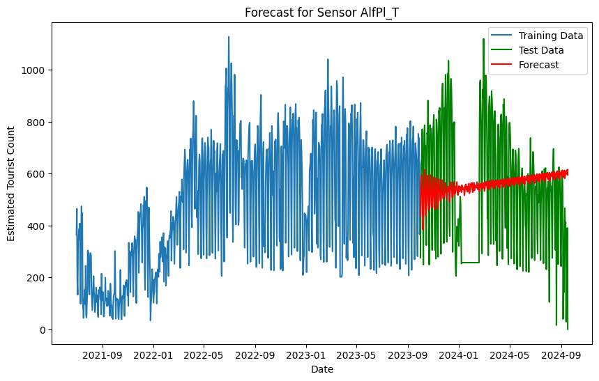

```
Processing sensor: BirArt1109_T
AIC for sensor BirArt1109_T: 956.1690151018729
BIC for sensor BirArt1109_T: 970.8294270374276
RMSE for sensor BirArt1109_T: 442.9249543675149
Forecast for sensor BirArt1109_T:
2024-08-16     988.810964
2024-08-17     652.606277
2024-08-18     728.489561
2024-08-19     641.428981
2024-08-20     642.115267
2024-08-21    1139.273023
2024-08-22     830.915185
2024-08-23    1432.328409
2024-08-24     842.953869
2024-08-25     877.438840
2024-08-26     900.879740
2024-08-27     770.718593
2024-08-28     887.326743
2024-08-29     768.039704
2024-08-30     705.910401
2024-08-31     706.217852
2024-09-01     651.287145
2024-09-02    1177.076864
2024-09-03     860.709042
2024-09-04    1498.350877
2024-09-05     869.545729
2024-09-06     909.696156
2024-09-07     929.320876
2024-09-08     802.940549
2024-09-09     920.660458
2024-09-10     798.948120
2024-09-11     738.369114
2024-09-12     737.692263
2024-09-13     683.391093
2024-09-14    1208.879279
2024-09-15     892.552109
2024-09-16    1529.702804
Freq: D, Name: predicted_mean, dtype: float64

Forecast Increase for sensor BirArt1109_T: 540.8918394666667
```

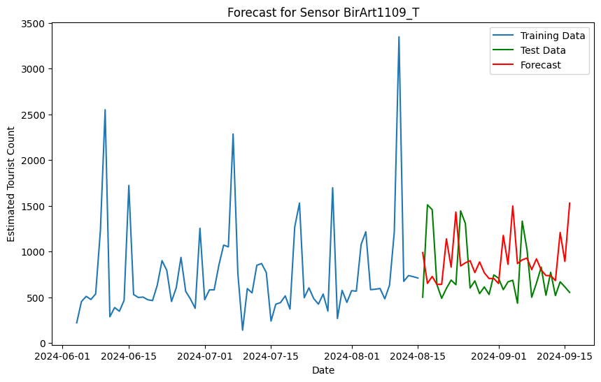

```
Processing sensor: BirFed1120_T
AIC for sensor BirFed1120_T: 3364.9341443255435
BIC for sensor BirFed1120_T: 3388.363897040566
RMSE for sensor BirFed1120_T: 557.2038567633205
Forecast for sensor BirFed1120_T:
2024-06-13    460.393231
2024-06-14    706.954203
2024-06-15    839.023079
2024-06-16    792.986733
2024-06-17    672.864418
                 ...
2024-09-12    687.916497
2024-09-13    678.363344
2024-09-14    770.623048
2024-09-15    759.059300
2024-09-16    717.599718
Freq: D, Name: predicted_mean, Length: 96, dtype: float64

Forecast Increase for sensor BirFed1120_T: 257.20648658525795
```

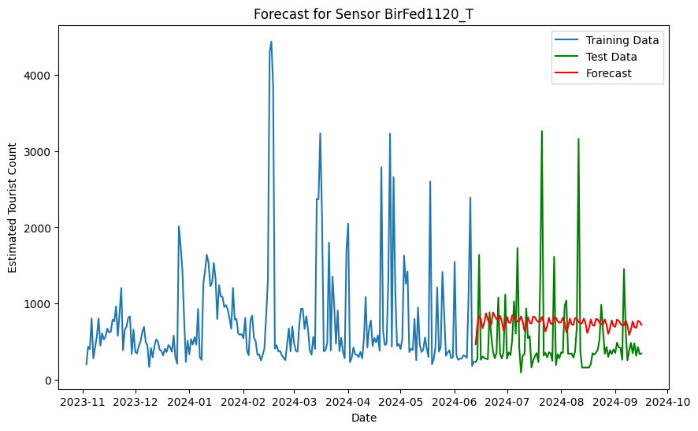

```
Processing sensor: Bou231_T
AIC for sensor Bou231_T: 11956.855181168994
BIC for sensor Bou231_T: 11989.725773588403
RMSE for sensor Bou231_T: 715.5533563500785
Forecast for sensor Bou231_T:
2023-10-01    1923.998335
2023-10-02    1918.734200
2023-10-03    1932.407043
2023-10-04    1840.279007
2023-10-05    1833.852886
                 ...
2024-09-13    2287.117458
2024-09-14    2244.432852
2024-09-15    2263.083414
2024-09-16    2207.823128
2024-09-17    2225.355281
Freq: D, Name: predicted_mean, Length: 353, dtype: float64

Forecast Increase for sensor Bou231_T: 301.3569463905783
```

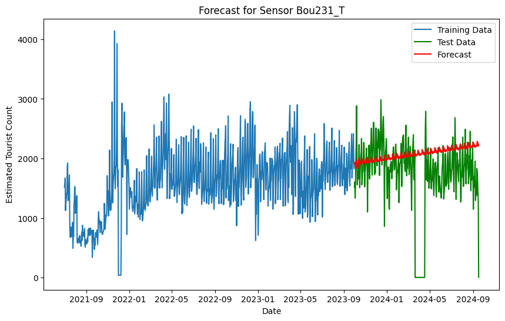

```
Processing sensor: Bou283_T
AIC for sensor Bou283_T: 12552.747689980355
BIC for sensor Bou283_T: 12585.618282399764
RMSE for sensor Bou283_T: 1187.4676361135944
Forecast for sensor Bou283_T:
2023-10-01    2883.126370
2023-10-02    3279.205315
2023-10-03    3462.738333
2023-10-04    3336.364025
2023-10-05    3293.769262
                 ...
2024-09-13    3769.056524
2024-09-14    3794.494893
2024-09-15    3767.481414
2024-09-16    3657.449570
2024-09-17    3744.194329
Freq: D, Name: predicted_mean, Length: 353, dtype: float64

Forecast Increase for sensor Bou283_T: 861.0679590603677
```

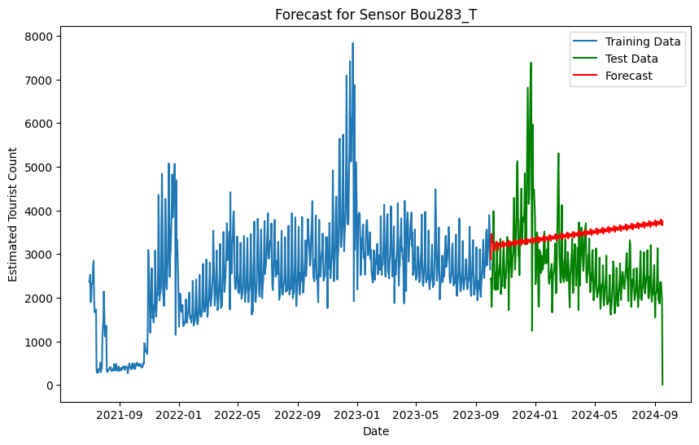

```
Processing sensor: Bou292_T
AIC for sensor Bou292_T: 12940.607533550628
BIC for sensor Bou292_T: 12973.478125970038
RMSE for sensor Bou292_T: 1249.1253237095927
Forecast for sensor Bou292_T:
2023-10-01    3487.099093
2023-10-02    3266.418029
2023-10-03    3269.310105
2023-10-04    3015.800792
2023-10-05    3326.546792
                 ...
2024-09-13    3958.879798
2024-09-14    3883.644830
2024-09-15    3954.609502
2024-09-16    3858.489209
2024-09-17    3981.771388
Freq: D, Name: predicted_mean, Length: 353, dtype: float64

Forecast Increase for sensor Bou292_T: 494.67229532426563
```

[75 more figures not shown]

```python
# ARIMA model
results = []
sensor_groups = data_1_3_estimation.groupby('sensor_name')
# Time serires model fit and forcast for each areas
for sensor_name, group in sensor_groups:
    if len(group) >= 10:
        print(f"Processing sensor: {sensor_name}")
        ts_data = group.set_index('year_day')['estimated_tourist_count']
        ts_data = ts_data.asfreq('D')
        ts_data = ts_data.ffill()
        ts_data = ts_data.astype(int)

        # Data split
        train_size = int(len(ts_data) * 0.7)
        train, test = ts_data[:train_size], ts_data[train_size:]

        # SARIMA
        model = SARIMAX(train, order=(2, 1, 2), seasonal_order=(1, 1, 1, 12))
        # model = ARIMA(train, order=(3, 1, 2)) Arima model
        model_fit = model.fit()

        # Prediction for test data
        forecast = model_fit.forecast(steps=len(test))

        # RMSE
        rmse = np.sqrt(mean_squared_error(test, forecast))

        # Forcast_increase
        forecast_increase = forecast.iloc[-1] - forecast.iloc[0]

        # AIC, BIC
        aic = model_fit.aic
        bic = model_fit.bic
        print(f"AIC for sensor {sensor_name}: {aic}")
        print(f"BIC for sensor {sensor_name}: {bic}")

        # Results
        results.append({
            'sensor_name': sensor_name,
            'rmse': rmse,
            'forecast_increase': forecast_increase,
        })

        # Results print
        print(f"RMSE for sensor {sensor_name}: {rmse}")
        print(f"Forecast for sensor {sensor_name}:\n{forecast}\n")
        print(f"Forecast Increase for sensor {sensor_name}: {forecast_increase}\n")

        # Visualization
        plt.figure(figsize=(10, 6))
        plt.plot(train.index, train, label='Training Data')
        plt.plot(test.index, test, label='Test Data', color='green')
        plt.plot(test.index, forecast, label='Forecast', color='red')
        plt.title(f'Forecast for Sensor {sensor_name}')
        plt.xlabel('Date')
        plt.ylabel('Estimated Tourist Count')
        plt.legend()
        plt.show()


    else:
        print(f"Skipping sensor {sensor_name} due to insufficient data.")

# result
results_df = pd.DataFrame(results)
```

Perform time series prediction for each sensor using daily pedestrian data and the estimated tourist data.

```python
# Filtering the top 10 sensors
top_10 = results_df.sort_values(by='rmse').nlargest(10, 'forecast_increase')
print(top_10)
```

```
   sensor_name         rmse  forecast_increase
23    Col700_T  1753.170327        3023.296543
63      RMIT_T  1659.274072        2049.594714
60       QVN_T  1170.318378        1466.542436
21    Col620_T   976.372848        1394.464178
76       Swa31  4153.878751        1290.145887
24      ElFi_T  1069.836633        1161.107265
55      MCEC_T  1379.774349        1106.678755
73    Swa123_T  1626.819741        1100.877376
25    Eli250_T  1075.237477         964.489569
75    Swa295_T  1479.962155         922.407188
```

List the top 10 sensors where the number of tourists is expected to increase the most by calculating the difference between the first and last predicted values.

```python
# 'top_10_results'
data_for_join  = data_1_1_estimation.drop_duplicates(subset=['sensor_name'], keep='first')
# 'left join'
top_10_results = pd.merge(top_10, data_for_join, on='sensor_name', how='left')
print(top_10_results)
```

```
  sensor_name         rmse  forecast_increase  year_month  \
0    Col700_T  1753.170327        3023.296543  2021-07-31
1      RMIT_T  1659.274072        2049.594714  2021-07-31
2       QVN_T  1170.318378        1466.542436  2021-07-31
3    Col620_T   976.372848        1394.464178  2021-07-31
4       Swa31  4153.878751        1290.145887  2021-07-31
5      ElFi_T  1069.836633        1161.107265  2021-07-31
6      MCEC_T  1379.774349        1106.678755  2021-07-31
7    Swa123_T  1626.819741        1100.877376  2021-07-31
8    Eli250_T  1075.237477         964.489569  2021-07-31
9    Swa295_T  1479.962155         922.407188  2021-07-31

                     location  pedestriancount   latitude   longitude  \
0  -37.81982992, 144.95102555            82497 -37.819830  144.951026
1  -37.80825648, 144.96304859           137066 -37.808256  144.963049
```

[output cut: 20 more lines]

Rematch the top_10 results with location , the pedestrian couting, and estimated tourist couting data.

```python
# 'Find the closest tourist location for each sensor based on 'top_10_results'
matching_results = []

# 'top_10_results'
for i, row_sensor in top_10_results.iterrows():
    min_distance = float('inf')
    closest_location = None
    closest_arttype = None
    closest_lat = None
    closest_lon = None

    # 'tourist spots'
    for j, row_tourist in data_3_cleaned.iterrows():
        distance = haversine(row_sensor['latitude'], row_sensor['longitude'],
                             row_tourist['latitude'], row_tourist['longitude'])

        # updating tourist spots
        if distance < min_distance:
            min_distance = distance
            closest_location = row_tourist['name']
            closest_arttype = row_tourist['asset_type']
            closest_lat = row_tourist['latitude']
            closest_lon = row_tourist['longitude']

    # Save results
    matching_results.append({
        'sensor_name': row_sensor['sensor_name'],
        'sensor_latitude': row_sensor['latitude'],
        'sensor_longitude': row_sensor['longitude'],
        'closest_tourist_location': closest_location,
        'arttype': closest_arttype,
        'tourist_latitude': closest_lat,
        'tourist_longitude': closest_lon,
        'distance_km': min_distance
    })

# Printing result
matching_results_df = pd.DataFrame(matching_results)
print(matching_results_df)
```

```
  sensor_name  sensor_latitude  sensor_longitude  \
0    Col700_T       -37.819830        144.951026
1      RMIT_T       -37.808256        144.963049
2       QVN_T       -37.810578        144.964443
3    Col620_T       -37.818880        144.954492
4       Swa31       -37.816686        144.966897
5      ElFi_T       -37.817980        144.965034
6      MCEC_T       -37.824018        144.956044
7    Swa123_T       -37.814880        144.966088
8    Eli250_T       -37.812585        144.962578
9    Swa295_T       -37.811015        144.964295

          closest_tourist_location   arttype  tourist_latitude  \
0                        Feng Shui       Art        -37.819823
1           Architectural Fragment       Art        -37.809828
```

[output cut: 20 more lines]

Match the top_10 sensors with the closest tourist spots.

```python
# color list for matched data
colors = ['red', 'blue', 'green', 'purple', 'orange', 'darkred', 'lightred',
          'beige', 'darkblue', 'darkgreen']

# Creating a map
map_top_10 = folium.Map(location=[-37.80841814, 144.95906317], zoom_start=14, width=1000, height=600, control_scale=True)
# top_10_results
for index, row in matching_results_df.iterrows():
    color = colors[index % len(colors)]
    # sensor_location
    folium.CircleMarker(
        location=[row['sensor_latitude'], row['sensor_longitude']],
        radius=5,
        color=color,
        fill=True,
        fill_color=color,
        fill_opacity=0.6,
        popup=f"Sensor: {row['sensor_name']}<br>Count: {row['distance_km']:.2f} km to closest tourist spot",
    ).add_to(map_top_10)

    # tourist spots
    folium.Marker(
        location=[row['tourist_latitude'], row['tourist_longitude']],
        popup=f"Name: {row['closest_tourist_location']}<br>Type: {row['arttype']}",
        icon=folium.Icon(color=color, icon='info-sign')
    ).add_to(map_top_10)


# Adding a legend
legend_html_2 = '''
<div style="position: fixed;
     top: 10px; left: 10px; width: 150px; height: 90px;
     border:2px solid grey; z-index:9999; font-size:14px;
     background-color: white; padding: 10px;">
     <b>Legend</b><br>
     <i style="color:green;" class="fa fa-circle"></i> Nearest Sensor to Tourist Spot<br>
     <i style="color:green;" class="fa fa-info-circle"></i> Top 10 Tourist Spots</div>
'''
map_top_10.get_root().html.add_child(folium.Element(legend_html_2))

# Map save
map_top_10.save('map_top_10.html')
# Display map
display(map_top_10)
```

Make this Notebook Trusted to load map: File -> Trust Notebook

[interactive chart not shown]

Visualize the matching of top_10 sensors and tourist spots on a map.